# Week 4: Numerical and graphical summaries

GV900 Political Explanation

Daina Chiba

02 October, 2019

# Topics for today

We have three main goals for this week’s lab session:

- learn how to install and load **R packages**;
- learning how to **import datasets** from a file;
- learning how to **summarize** categorical and numerical data.

## Preparation

### 1. Folder

If you haven’t done so already, create a folder named `GV900` somewhere on your computer (could be on your desktop, documents folder, etc. Choose wherever you find it easy to access).

### 2. Download files from Moodle

Download all the files for today from Moodle, including:  
* `gv900-week4.html`  
* `gv900-week4-exercise.R`  
* `worlddata.csv`

### 3. Store

Move all the files you downlaoded to the `GV900` folder.

# 1. Loading R packages

We have been using some R functions such as `summary()`, `sqrt()`, etc. These simple functions come with the base R installation and so we can use them without doing any additional installation.

One of the great advantages of R is the availability of **packages** – a collection of additional functions and data sets. To use a certain R package, we need to do two things:

1. Install it
2. Load it

Installation must be done just once per computer. For example, once you install a package called `ggplot2` to your computer, you won’t need to install it ever again. However, you still need to **load the package** each time you start a new R session (i.e., each time you begin RStudio).

## 1-2. Loading a package

Let’s first see how to do (2) = loading a package.

To load a package, we use the `library()` function. Let’s load a package called `ggplot2`, which contains a lot of graphic functions.

```r
library(ggplot2)
```

What happened on your computer?

If you are using your own computer, you might have got an error message saying “Error in library(ggplot2) : there is no package called ‘ggplot2’.”

This happened because you haven’t installed this package.

If, on the other hand, you are using a lab computer, you probably didn’t get any error message. This is because someone has already installed this package to the computer you are using. Remember we need to install a package once per computer.

## 1-1. Installing a package

To install an R package, we use the `install.packages()` function.

```r
install.packages("ggplot2", dependencies = TRUE)
```

`ggplot2` is the name of the package we install.  
We put the `dependencies = TRUE` option here because we want to install all the additional packages that `ggplot2` depends on.

Some packages depend on other packages. For example, the `ggplot2` package depends on eight other packages (`plyr`, `digest`, `grid`, `gtable`, `reshape2`, `scales`, `proto`, and `MASS`), each of which might also depend on yet other packages. Loading the `ggplot2` package requires that we also load all the packages that it depends on, which means that we need to install all these packages. The `dependencies = TRUE` option guarantees that they are installed.

Note that, for installation, you need to have an internet access.

Installation might take a while, but the good news is that you don’t need to do this again for `ggplot2`.

Once the installation is done, you can now load the `ggplot2` package. Try the following:

```r
library(ggplot2)
```

If you don’t get any error message, it means you have successfully loaded this package. Remember that loading must be done every time we start R (R studio).

Let’s install another package, called `tidyverse`.

```r
install.packages("tidyverse", dependencies = TRUE)
```

```r
library(tidyverse)
```

# 2. Importing data sets from a file

We have learned how to work with `data.frame` objects last week. We created a mini data set using the `data.frame` function. In practice, we work with data sets that are much larger than the mini data set we created. Moreover, we usually import such data sets from a file, not by typing in information on our own.

To read in (=import) a data set from a file, we use `read_XXX` functions, such as:

| Function | File |
| --- | --- |
| read_csv | Comma-separated text file |
| read_table | Tab-separated text file |
| read_dta | Stata file |
| read_spss | SPSS file |
| read_xlsx | Excel file |

We will use the `read_csv()` function today. We will learn others in the future.

Let’s use the read_csv function and import the `worlddata.csv` data set we discussed in the lecture.

```r
wd <- read_csv("worlddata.csv")
```

What happened on your computer?

- You haven’t downloaded the `worlddata.csv` file from Moodle;
- You haven’t moved the `worlddata.csv` file to the `GV900` folder;
- You have done both, but R doesn’t know where `GV900` is.

Please do the first two if you haven’t done so. Now we will see how to resolve the third issue.

## Setting the path

When you do some file operations in R (such as loading a data set from a file, or saving data, graphs, or outputs into a file), we often need to tell R the exact location (address / path) of the file.

Locations on a computer are called “path”. A path is like an address. It identifies the location of files and folders on a computer.

When using functions such as `read_csv()`, R looks for files contained in one folder and one folder only. The folder that R thinks R is locaed currently is called **current directory** or **working directory**.

**Directory** is just another name for **folder**. So, the working directory refers to the folder that R searches when trying to open a file.

When you open RStudio by double-clicking on a script file (such as the present file `gv900-week4-Rcode.R`), the working directory is automatically set to the folder that contains the script file.

Therefore, if you have opened this `gv900-week4-Rcode.R` file saved in `GV900` today, then the working directory has been correctly set to `GV900`. As long as the data file `worlddata.csv` is located in the `GV900` folder, you should have been able to load the data set from this file.

If not, we need to change the working directory.

To find out what the present working folder on R, we use the `getwd()` function (short for **get w(orking) d(irectory)**).

```r
getwd()
```

If you are on a lab computer, R will tell you something like: `m:/pc/desktop/GV900`.

If you are on a Mac computer, R will tell you something like: `Users/daina/Desktop/GV900` or `Users/daina/Documents/GV900`.

To change the working directory, we use the `setwd()` function (short for **set w(orking) d(irectory)**).

If you are on a lab computer, execute the following. Do not execute it if you are on your own computer.

```r
setwd("m:/pc/desktop/GV900")
```

If you are using your own Mac computer, execute the following:  
(You need to replace `daina` with your own username. You may also need to replace “Desktop” with “Documents” or something, depending on where you created the `GV900` folder.)

```r
setwd("Users/daina/Desktop/GV900")
```

If you are using your own Windows computer, the exact path would depend on how your computer is configured, so you probably want to ask for your GTA’s help.

Another, possibly easier, option is to close RStudio once, and re-open it by double-clicking on the `gv900-week4-Rcode.R` file. This will automatically set the path correctly, so there is no need to run `setwd()`.

Now, let’s see if the path is set correctly.

```r
getwd()
```

If it shows the location of the `GV900` folder that contains the `worlddata.csv` file, you could execute the following again.

```r
wd <- read_csv("worlddata.csv")
```

## Exploring the data

Whenever you read in a data set from a file, it’s always a good idea to take a look at it first to have an idea about what it looks like.

There are a number of ways to do this. For example, we can simply type the name of the object that stores the data set.

```r
wd
```

```
# A tibble: 174 x 39
   country_name colony gwcode  cowc iso3c frac_eth frac_eth3 frac_lan
   <chr>        <chr>   <int> <int> <chr>    <dbl> <chr>        <dbl>
 1 United Stat… Unite…      2     2 USA      0.490 Medium      0.251
 2 Canada       Unite…     20    20 CAN      0.712 High        0.577
 3 Bahamas      Unite…     31    31 BHS      0.423 Medium      0.185
 4 Cuba         Spain      40    40 CUB      0.591 Medium     NA
 5 Haiti        France     41    41 HTI      0.095 Low        NA
 6 Dominican R… Spain      42    42 DOM      0.429 Medium      0.0395
 7 Jamaica      Unite…     51    51 JAM      0.413 Medium      0.110
 8 Trinidad an… Unite…     52    52 TTO      0.648 High        0.125
 9 Barbados     Unite…     53    53 BRB      0.142 Low         0.0926
10 Mexico       Spain      70    70 MEX      0.542 Medium      0.151
# … with 164 more rows, and 31 more variables: frac_lan3 <chr>,
#   frac_rel <dbl>, frac_rel3 <chr>, region <chr>, region7 <chr>,
#   religion <chr>, property_rights <dbl>, government_integrity <dbl>,
#   judicial_effectiveness <chr>, tax_burden <chr>,
#   government_spending <chr>, fiscal_health <dbl>,
#   business_freedom <dbl>, labor_freedom <dbl>, monetary_freedom <chr>,
#   trade_freedom <chr>, investment_freedom <chr>,
#   financial_freedom <chr>, union <dbl>, gdppc <int>, gdp <dbl>,
#   gini <dbl>, school <dbl>, pop <dbl>, unemp <dbl>, old <dbl>,
#   gdppc3 <chr>, femalerep <dbl>, pr <chr>, polity2 <int>,
#   democ_bmr <chr>
```

R also shows the first 8 columns and first 10 rows of the data set, followed by the names of the other 31 columns.

The `dim()` function tells us the dimension of data (i.e., the number of rows and the number of columns).

```r
dim(wd)
```

```
[1] 174  39
```

The `head()` and `tail()` functions let us see the first or last 5 rows of the data set.

```r
head(wd)
tail(wd)
```

The `glimpse()` function lets us glimpse the data set.

```r
glimpse(wd)
```

```
Observations: 174
Variables: 39
$ country_name           <chr> "United States of America", "Canada", "Ba…
$ colony                 <chr> "United Kingdom", "United Kingdom", "Unit…
$ gwcode                 <int> 2, 20, 31, 40, 41, 42, 51, 52, 53, 70, 80…
$ cowc                   <int> 2, 20, 31, 40, 41, 42, 51, 52, 53, 70, 80…
$ iso3c                  <chr> "USA", "CAN", "BHS", "CUB", "HTI", "DOM",…
$ frac_eth               <dbl> 0.4901111, 0.7124200, 0.4228451, 0.590800…
$ frac_eth3              <chr> "Medium", "High", "Medium", "Medium", "Lo…
$ frac_lan               <dbl> 0.2513707, 0.5771839, 0.1854935, NA, NA, …
$ frac_lan3              <chr> "Medium", "High", "Low", NA, NA, "Low", "…
$ frac_rel               <dbl> 0.8240782, 0.6957678, 0.6814594, 0.505935…
$ frac_rel3              <chr> "High", "High", "High", "Medium", "Medium…
$ region                 <chr> "Northern America", "Northern America", "…
$ region7                <chr> "Western Europe and other developed count…
```

[output cut: 26 more lines]

We can also use **square brackets []**.

```r
wd[1:10, 1:5]
```

```
# A tibble: 10 x 5
   country_name             colony         gwcode  cowc iso3c
   <chr>                    <chr>           <int> <int> <chr>
 1 United States of America United Kingdom      2     2 USA
 2 Canada                   United Kingdom     20    20 CAN
 3 Bahamas                  United Kingdom     31    31 BHS
 4 Cuba                     Spain              40    40 CUB
 5 Haiti                    France             41    41 HTI
 6 Dominican Republic       Spain              42    42 DOM
 7 Jamaica                  United Kingdom     51    51 JAM
 8 Trinidad and Tobago      United Kingdom     52    52 TTO
 9 Barbados                 United Kingdom     53    53 BRB
10 Mexico                   Spain              70    70 MEX
```

This tells R to show the first 10 rows and first 5 columns.

When working with a large data set like this one, you may want to use the spreadsheet view (just like Excel). To do so, we use the `View()` function, which opens a spreadsheet tab in the script pane.

```r
View(wd)
```

# 3. Summarizing data

Now we will use numerical and graphical methods to summarize data. As we learned in the lecture, we will need different methods for different types of data (categorical or numerical).

## Categorical variables

As we saw in the lecture, there is a variable called `colony` in the data set that records the former colonial master country for each observation. Let’s see how to summarize the information contained in this variable.

To access a variable included in a data frame object, we use the `$` symbol.

```r
wd$colony
```

```
 [1] "United Kingdom"  "United Kingdom"  "United Kingdom"
 [4] "Spain"           "France"          "Spain"
 [7] "United Kingdom"  "United Kingdom"  "United Kingdom"
[10] "Spain"           "United Kingdom"  "Spain"
[13] "Spain"           "Spain"           "Spain"
[16] "Spain"           "Spain"           "Spain"
[19] "Spain"           "United Kingdom"  "Netherlands"
[22] "Spain"           "Spain"           "Portugal"
[25] "Spain"           "Spain"           "Spain"
[28] "Spain"           "Spain"           "Never"
[31] "United Kingdom"  "Never"           "Netherlands"
[34] "Netherlands"     "Never"           "Never"
[37] "Never"           "Never"           "Never"
[40] "Germany"         "Never"           "Never"
[43] "Austria-Hungary" "Austria-Hungary" "Never"
[46] "United Kingdom"  "Turkey"          "Turkey"
[49] "Turkey"          "Austria-Hungary" "Turkey"
[52] "Austria-Hungary" "Turkey"          "United Kingdom"
[55] "Turkey"          "Turkey"          "Turkey"
[58] "Never"           "Russia"          "Russia"
[61] "Russia"          "Russia"          "Russia"
[64] "Turkey"          "Russia"          "Russia"
[67] "Never"           "Never"           "Never"
[70] "Never"           "Never"           "Portugal"
[73] "Portugal"        "Spain"           "United Kingdom"
 [ reached getOption("max.print") -- omitted 99 entries ]
```

Since the `country` variable is stored in the first column and the `colony` variable in the second column, we can do the following:

```r
wd[, 1:2]
```

```
# A tibble: 174 x 2
   country_name             colony
   <chr>                    <chr>
 1 United States of America United Kingdom
 2 Canada                   United Kingdom
 3 Bahamas                  United Kingdom
 4 Cuba                     Spain
 5 Haiti                    France
 6 Dominican Republic       Spain
 7 Jamaica                  United Kingdom
 8 Trinidad and Tobago      United Kingdom
 9 Barbados                 United Kingdom
10 Mexico                   Spain
# … with 164 more rows
```

This shows the first and second columns for the first 10 rows. Alternatively, we can do the following to get the same output.

```r
wd %>% select(country_name, colony)
```

```
# A tibble: 174 x 2
   country_name             colony
   <chr>                    <chr>
 1 United States of America United Kingdom
 2 Canada                   United Kingdom
 3 Bahamas                  United Kingdom
 4 Cuba                     Spain
 5 Haiti                    France
 6 Dominican Republic       Spain
 7 Jamaica                  United Kingdom
 8 Trinidad and Tobago      United Kingdom
 9 Barbados                 United Kingdom
10 Mexico                   Spain
# … with 164 more rows
```

### Pipe %>%

The expression `%>%` is called a **pipe** operator. This takes the output of one statement (`wd`) and makes it the input (argument) of the next statement (`select(country_name, colony)`). You could think of this as a “THEN” in English. The above code means: “take the `wd` and **then** select the variables `country_name` and `colony`.”

### Why do we use pipes?

The point of using pipes is to streamline your code. When we do complex operations, our code will often contain a lot of parentheses, `(` and `)`, with one nesting another. This would make our R code hard to read and understand. For example,[^1]

```r
x <- c(0.109, 0.359, 0.63, 0.996, 0.515, 0.142, 0.017, 0.829, 0.907)

# Compute the logarithm of 'x'', return suitably lagged and iterated
# differences, compute the exponential function, and round the result.
round(exp(diff(log(x))), 1)
```

```
[1]  3.3  1.8  1.6  0.5  0.3  0.1 48.8  1.1
```

If we use pipes, we can re-write it as:

```r
x %>% log() %>% diff() %>% exp() %>% round(1)
```

```
[1]  3.3  1.8  1.6  0.5  0.3  0.1 48.8  1.1
```

This is much easier to understand than `round(exp(diff(log(x))), 1)`, although these two commands have the same meaning.

Note that the pipe operator `%>%` is included in the `magrittr` package, so you need to load this package before using it. However, when we call the `tidyverse` package, `magrittr` is automatically loaded.

Note also that there is a keyboard shortcut for the `%>%` operator. On a Mac machine, it is `shift + command + m`. On a Windows machine, it is `shift + control + m`.

### Numerically summarize categorical variables

Now, going back to summarizing the colony variable, we will create what’s called a **frequency table**, which summarizes a nominal-level variable like this.

A frequency table summarizes a nominal-level variable in a concise way so we can easily see things like what the “typical” values are, how frequent these typical values appear, etc.

One way to create a frequency table is to use the `table()` function, as follows:

```r
table(wd$colony)
```

```
Austria-Hungary         Belgium           China          France
              4               3               1              25
        Germany           Italy           Japan     Netherlands
              1               3               2               4
          Never        Portugal          Russia           Spain
             25               7              12              20
         Turkey  United Kingdom
             19              48
```

Alternatively, we could use the pipe operator (just to practice how we use it).

```r
wd$colony %>% table()
```

```
.
Austria-Hungary         Belgium           China          France
              4               3               1              25
        Germany           Italy           Japan     Netherlands
              1               3               2               4
          Never        Portugal          Russia           Spain
             25               7              12              20
         Turkey  United Kingdom
             19              48
```

The output above nicely summarizes the information contained in the colony variable. We can see the (raw) frequencies with which each value is observed in the data set. For example, there are 4 observations (countries) that are former colonies of Austria-Hungary, 3 observations that are former colonies of Belgium, 1 former colony of China, etc.

To make it look more like the frequency table you saw in the lecture slide, we can make it vertical using the `data.frame()` function.

```r
wd$colony %>% table() %>% data.frame()
```

```
                 . Freq
1  Austria-Hungary    4
2          Belgium    3
3            China    1
4           France   25
5          Germany    1
6            Italy    3
7            Japan    2
8      Netherlands    4
9            Never   25
10        Portugal    7
11          Russia   12
12           Spain   20
13          Turkey   19
14  United Kingdom   48
```

This code means, “Take the colony variable from the `wd` data set, then create a frequency table, then make the frequency table into a data frame”. Alternatively, you could write `data.frame(table(wd $ colony))` to get the same result.

### Graphically summarize categorical variables

Another way to summarize the information contained in a categorical (nominal-level) variable is to create a bar chart, which is a graphical representation of a frequency table.

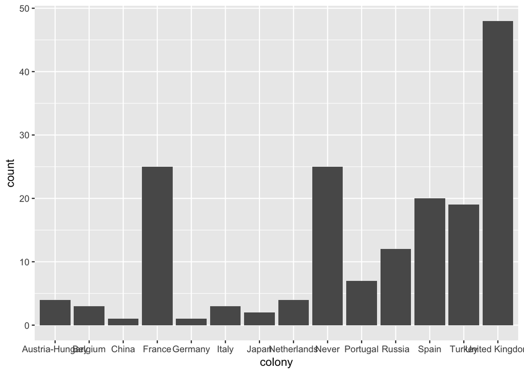

```r
ggplot(wd, aes(x = colony)) + geom_bar()
```

The first part tells R that `wd` is the name of the data frame object that contains a variable(s) we want to plot.

The second part, the `aes` option (short for aesthetic) tells R which variable(s) we want to plot. We don’t need to enclose variable names with “”.

Finally, the last part, + geom_bar(), tells R that we want a bar chart. We will use `geom_histogram()` to create a histogram, `geom_boxplot()` to create a box plot, `geom_points()` to create a scatterplot, etc. (More on this next week).

## Numerical variables

This data set also contains a number of numerical variables. One of them is called `femalerep`, which we saw in the lecture.

```r
wd$femalerep
```

```
 [1] 19.40 26.30    NA 48.90  2.50 26.80 17.50 31.00 16.70 42.60    NA
[12] 14.00 25.80 32.14 45.70 35.10 18.30 18.70 22.16 31.90 25.49 38.00
[23] 27.70 10.70 53.10 13.80 15.80 38.90 20.20 32.00 22.20 36.00 38.00
[34] 28.30 39.00 32.50 39.10 34.80 31.00 28.04 34.40 10.10 20.00 20.00
[45] 31.00 11.90 27.90 23.50 38.30 18.50 21.40 36.70 18.30 17.90 23.80
[56] 22.80 20.70 15.80 26.70 16.00 21.30 12.30 34.50 18.10 16.00 16.80
[67] 42.00 43.60 41.40 37.40 38.10 23.60 13.70 20.00 10.30
 [ reached getOption("max.print") -- omitted 99 entries ]
```

This variable records the percentage of women in the lower house of parliament for each country, measured in the year 2017.

To see what value each country has, we can do

```r
wd[c("country_name", "femalerep")]
```

```
# A tibble: 174 x 2
   country_name             femalerep
   <chr>                        <dbl>
 1 United States of America      19.4
 2 Canada                        26.3
 3 Bahamas                       NA
 4 Cuba                          48.9
 5 Haiti                          2.5
 6 Dominican Republic            26.8
 7 Jamaica                       17.5
 8 Trinidad and Tobago           31
 9 Barbados                      16.7
10 Mexico                        42.6
# … with 164 more rows
```

or

```r
wd %>% select(country_name, femalerep)
```

```
# A tibble: 174 x 2
   country_name             femalerep
   <chr>                        <dbl>
 1 United States of America      19.4
 2 Canada                        26.3
 3 Bahamas                       NA
 4 Cuba                          48.9
 5 Haiti                          2.5
 6 Dominican Republic            26.8
 7 Jamaica                       17.5
 8 Trinidad and Tobago           31
 9 Barbados                      16.7
10 Mexico                        42.6
# … with 164 more rows
```

### Numerically summarize numerical variables

Let’s now summarize this variable.

To summarize the information contained in a numeric (interval-level) variable like this one, we identify the central tendency (mean & median) and dispersion (range, inter-quartile range, standard deviation, variance), as we learned in the lecture.

The `summary()` function gives us summary values including the five number summary, mean, and the number of observations with missing values.

```r
summary(wd$femalerep)
```

```
   Min. 1st Qu.  Median    Mean 3rd Qu.    Max.    NA's
   0.00   14.15   20.55   22.37   31.00   61.30       4
```

- Min. = Q0 = minimum = 0th percentile
- 1st Qu. = Q1 = 1st quartile = 25th percentile = median of the lower half of the data
- Median = Q2 = median = 50th percentile
- Mean = mean (average)
- 3rd Qu. = Q3 = 3rd quartile = 75th percentile = median of the upper half of the data
- Max. = Q4 = 4th quartile = 100th percentile = maximum value

If we just want mean or median, we can use the `mean()` or `median()` functions. However, it won’t work if the variable contains some missing values.

```r
mean(wd$femalerep)
```

```
[1] NA
```

```r
median(wd$femalerep)
```

```
[1] NA
```

NA means “Not available”. This happened because of missing values. What is a **missing value**? Look at the raw values of `femalerep` variable.

```r
wd %>% select(country_name, femalerep)
```

```
# A tibble: 174 x 2
   country_name             femalerep
   <chr>                        <dbl>
 1 United States of America      19.4
 2 Canada                        26.3
 3 Bahamas                       NA
 4 Cuba                          48.9
 5 Haiti                          2.5
 6 Dominican Republic            26.8
 7 Jamaica                       17.5
 8 Trinidad and Tobago           31
 9 Barbados                      16.7
10 Mexico                        42.6
# … with 164 more rows
```

Look at the value for Bahamas (third from the top), which says NA. This means that the people who created this variable could not find a value of this variable for this observation. There are as many as 4 observations where `femalerep` is missing, as we see from the output of `summary()`:

```r
summary(wd$femalerep)
```

```
   Min. 1st Qu.  Median    Mean 3rd Qu.    Max.    NA's
   0.00   14.15   20.55   22.37   31.00   61.30       4
```

When a variable contains a missing value, we have to tell R to ignore them when using functions such as the `mean()` and `median()` functions. That way, R will report the mean/median value of the variable, excluding the observations with missing values.

To do so, we use the `na.rm` option, short for NA R(e)M(ove), as follows:

```r
mean(wd$femalerep, na.rm = TRUE)
```

```
[1] 22.36759
```

```r
median(wd$femalerep, na.rm = TRUE)
```

```
[1] 20.55
```

To summarize the dispersion of a numerical variable, we calculate **standard deviation** and **variance** (in addition to the range and IQR we have already calculated using the `summary()` function).

The `sd()` function calculates the standard deviation, and the `var()` function calculates the variance (square of the standard deviation).

```r
sd(wd$femalerep, na.rm = TRUE)
```

```
[1] 11.6915
```

```r
var(wd$femalerep, na.rm = TRUE)
```

```
[1] 136.6912
```

The standard deviation is about 12. This means that the values are away from the mean by about +12 or -12, on average. (Some values are away from the mean by more than +12 or less than -12, but if we take the average distance it’s plus or minus 12).

So, to report the summary of this variable, we calculate mean, the standard deviation, and the five number summary, instead of reporting all the observed values. These numbers collectively describe the distribution of a numerical variable.

```r
summary(wd$femalerep)
```

```
   Min. 1st Qu.  Median    Mean 3rd Qu.    Max.    NA's
   0.00   14.15   20.55   22.37   31.00   61.30       4
```

```r
sd(wd$femalerep, na.rm = TRUE)
```

```
[1] 11.6915
```

Mean is about 22 and the standard deviation is about 12. The minimum is 0 and the maximum is about 61.

### Graphically summarize numerical variables

Another way of summarizing the information contained in numerical variables is to visualize the distribution of the variables. **Histogram** is one of the most commonly used graphical tool to summarize the central tendency and dispersion of numerical variables.

To draw a histogram using the `ggplot()` function, we write:

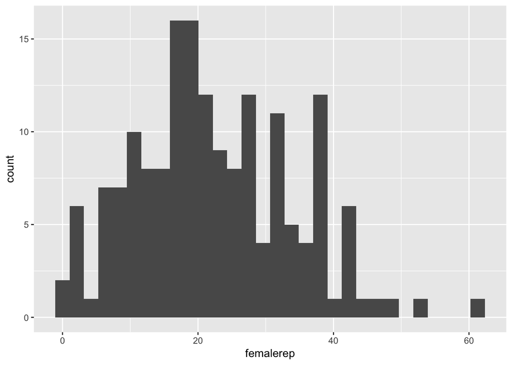

```r
ggplot(wd, aes(x = femalerep)) + geom_histogram()
```

Notice that we replace `x = colony` with `x = femalerep` and `geom_bar()` with `geom_histogram()` from before.

[^1]: The example is from https://www.datacamp.com/community/tutorials/pipe-r-tutorial